# R Lab 5 Key

## Setting Up: “RESPECT” Scale

For this week, you will be working with some of my old data on scale creation. The goal of this scale was to measure how K-12 teachers feel about the concept of respect in the classroom. Below I have included the questionnaire that the teachers took so that you can see the scale statement associated with each variable name.

*Please indicate your level of disagreement/agreement with each of the following statements*

`respect_1:` All children should be respected the same.  
`respect_2:` Children only learn the importance of earning respect when adults model the process.  
`respect_3:` Children should always respect all authority figures.  
`respect_4:` Children too often feel disrespected by adults, but they fail to consider how their own behavior drives the adult’s behavior.  
`respect_5:` Disrespect from an authority figure towards a child is excusable dependent on the situation.  
`respect_6:` Children cannot expect adults to respect them until they have demonstrated qualities and character worthy of respect.  
`respect_7:` Sometimes disrespect is not personal, and adults need to learn not to take disrespect from children so personally.  
`respect_8:` A child needs to earn an adult’s respect.  
`respect_9:` Children should only respect adults when adults earn the respect.  
`respect_10:` All children should be taught to give respect to all adults.  
`respect_11:` Children too often want to be treated as adults, but they need to learn that such treatment is earned.  
`respect_12:` When a child is disrespectful to an adult, it makes sense for the adult to reciprocate such behavior.  
`respect_13:` It is wrong for a child to disrespect an authority figure.  
`respect_14:` A child needs to earn an adult’s respect.  
`respect_15:` Disrespect from a child towards an authority figure is excusable dependent on the situation.  
`respect_16:` Children and adults deserve the same respect.  
`respect_17:` When an adult treats children unfairly, it is reasonable for the children to disrespect the adult.  
`respect_18:` Only after an adult has demonstrated worthy qualities and character, should the adult expect respect from children.  
`respect_19:` It is wrong for an authority figure to disrespect a child.  
`respect_20:` It is important to show kids respect in order to gain their respect.  
`respect_21:` Instead of blind respect toward adults, children should be taught how to judge when an adult is worthy of respect.  
`respect_22:` Adults must earned the respect of children.

### Libraries

```r
library(tidyverse)
library(psych)
library(scales)
library(forcats)
library(viridis)
library(GPArotation)
library(stats)
```

### Loading in our Data

```r
full.data <- read.csv("../Data/respect_data.csv")
head(full.data)
```

```
##   ResponseId respect_1 respect_2 respect_3 respect_4 respect_5 respect_6
## 1          1         7         5         2         4         1         1
## 2          2         7         7         7         6         1         2
## 3          3         7         5         6         5         1         1
## 4          4         7         7         6         6         2         6
## 5          5         7         7         4         5         1         1
## 6          6         5         7         6         4         4         5
##   respect_7 respect_8 respect_9 respect_10 respect_11 respect_12 respect_13
## 1         7         2         6          3          5          1          5
## 2         7         4         3          6          5          2          6
## 3         4         1         1          5          4          1          5
## 4         6         7         3          6          6          2          4
## 5         7         1         1          3          1          1          7
## 6         5         5         5          6          4          5          5
##   respect_14 respect_15 respect_16 respect_17 respect_18 respect_19 respect_20
## 1          2          5          7          6          6          7          7
## 2          3          3          7          3          5          7          7
## 3          1          2          5          3          2          6          5
## 4          6          4          3          6          4          6          6
## 5          1          6          7          4          4          7          1
## 6          6          5          5          5          6          4          6
##   respect_21 respect_22 years_teaching    AGREE   SDO    SJ
## 1          7          7             11 4.833333 1.375 3.750
## 2          3          5             18 4.416667 1.625 4.250
## 3          5          2             13 4.750000 1.750 7.000
## 4          6          3              7 3.250000 3.500 4.125
## 5          6          5             20 3.583333 1.000 2.875
## 6          6          6             12 3.833333 3.125 6.000
```

## Computing Alpha Reliability

The first step is to create a new dataframe that contains only the scale items and no extra variables. It is also necessary to have complete cases, this means omitting and data rows with missing data.

```r
resp.data <- full.data %>%
  select(c(respect_1:respect_22)) %>%
  na.omit()
```

### EXERCISE 1: Compute Initial Alpha

Fill in the blank below with the newly created dataset. When you have correctly done this, the code will run and give you the alpha.

```r
psych::alpha(resp.data, check.keys = TRUE)$total
```

```
##  raw_alpha std.alpha   G6(smc) average_r      S/N        ase     mean        sd
##  0.7779576 0.7725145 0.8480512 0.1337179 3.395885 0.02724711 3.600863 0.6152858
##   median_r
##  0.1207161
```

### EXERCISE 2: What is our intial alpha?

What is the raw_alpha we get from the code above?

## Factor Loadings

Next, we can get our factor loadings and see which items make the cutoff.

### EXERCISE 3: FILL IN DATA & CUTOFF

Fill in the blanks below to put the respect data and set the cutoff to 0.40.

```r
resp.loadings <- fa(resp.data, nfactors = 1, rotate = "oblimin", fm = "minres")
print(resp.loadings$loadings, cutoff = 0.4)
```

```
##
## Loadings:
##            MR1
## respect_1
## respect_2
## respect_3   0.637
## respect_4   0.546
## respect_5
## respect_6   0.460
## respect_7
## respect_8   0.592
## respect_9
## respect_10  0.548
## respect_11  0.473
## respect_12
## respect_13  0.514
## respect_14  0.586
## respect_15
## respect_16
## respect_17
## respect_18
## respect_19
## respect_20
## respect_21
## respect_22
##
##                  MR1
## SS loadings    3.415
## Proportion Var 0.155
```

We can also see visually what it looks like.

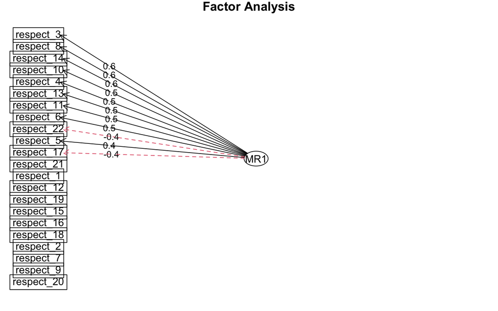

```r
fa.diagram(resp.loadings)
```

### EXERCISE 4: FINAL ITEMS

Here, write down which items made the final cut. Are any of them negative?

“respect_3”, “respect_4”, “respect_6”, “respect_8”, “respect_10”, “respect_11”, “respect_13”, “respect_14”

Above are the items that made the final cut. None of them are negative. This means that there are no items that need to be reverse scored.

## Scoring our Final Items

Now that we know which items to include, we want to score our scale and get the new alpha. By scoring the scale, every participant (teacher) will get one final summary score that represents how they responded to the scale.

First, we have to make a list of our variable names. If we have any reverse-score items we need to add a “-” to the name.

### EXERCISE 5: UPDATING ITEMS

Fill in the blanks below with the correct final variable names.

```r
keys.list <- list(resp.scale = c("respect_3", "respect_4", "respect_6",
                                 "respect_8", "respect_10", "respect_11",
                                 "respect_13", "respect_14"))
```

Next, we score the items and see the alpha. If you correctly created `keys.list` above, this should run without error.

```r
scoreItems(keys.list, resp.data, min = 1, max = 7) %>%
  summary()
```

```
## Call: scoreItems(keys = keys.list, items = resp.data, min = 1, max = 7)
##
## Scale intercorrelations corrected for attenuation
##  raw correlations below the diagonal, (unstandardized) alpha on the diagonal
##  corrected correlations above the diagonal:
##            resp.scale
## resp.scale       0.79
```

### EXERCISE 6: UPDATED ALPHA

What is our new alpha? Is it higher than our original alpha? By how much?

The original alpha was 0.78 and the new alpha is 0.79. It improved by 0.01.

Let’s look at some of the individual scores.

```r
head(scoreItems(keys.list, resp.data, min = 1, max = 7)$score)
```

```
##   resp.scale
## 1      3.000
## 2      4.875
## 3      3.500
## 4      5.875
## 5      2.875
## 6      5.125
```

Now, let’s add it to our dataset! Below I am creating a new variable called `RESPECT` that will hold the score for each teacher on the scale.

```r
full.data$RESPECT <- scoreItems(keys.list, full.data, min = 1, max = 7)$score
```

## Exploratory Data Visualization

For the final part of this lab, your task is to create two visualizations using the new `RESPECT` variable.

There are 4 potential variables for you to use in combination with `RESPECT`:

1. `AGREE`: This variable is from a personality scale and is called agreeableness. Agreeableness is a personality trait manifesting itself in individual behavioral characteristics that are perceived as kind, sympathetic, cooperative, warm, and considerate.
2. `SDO`: This variable is a score on the Social Dominance Orientation scale. Social dominance orientation is a personality trait measuring an individual’s support for social hierarchy and the extent to which they desire their in-group be superior to out-groups.
3. `SJ`: This variable is a score on the System Justification scale. System justification refers to a social psychological propensity to defend and bolster the status quo, that is, to see it as good, fair, legitimate, and desirable.
4. `years_teaching`: This refers to the number of years the teacher has been teaching.

### EXERCISE 7: CORRELATION 1

First, use cor.test() to find the correlation between `RESPECT` and one of the other 4 variables.

```r
cor.test(full.data$RESPECT, full.data$SDO)
```

```
##
##  Pearson's product-moment correlation
##
## data:  full.data$RESPECT and full.data$SDO
## t = 4.2071, df = 135, p-value = 4.686e-05
## alternative hypothesis: true correlation is not equal to 0
## 95 percent confidence interval:
##  0.1832050 0.4807253
## sample estimates:
##       cor
## 0.3404594
```

### EXERCISE 8: INTERPRET CORRELATION 1

There is a statistically significant (p < 0.01) positive correlation (r = 0.34) between feelings about children needing to respect authority and social dominance orientation.

### EXERCISE 9: GRAPH 1

Next, create a scatterplot showing the relationship between these two variables. Make sure you: add a theme, add a `geom_smooth` line with method = “lm”, and clean up the labels for the x and y axis.

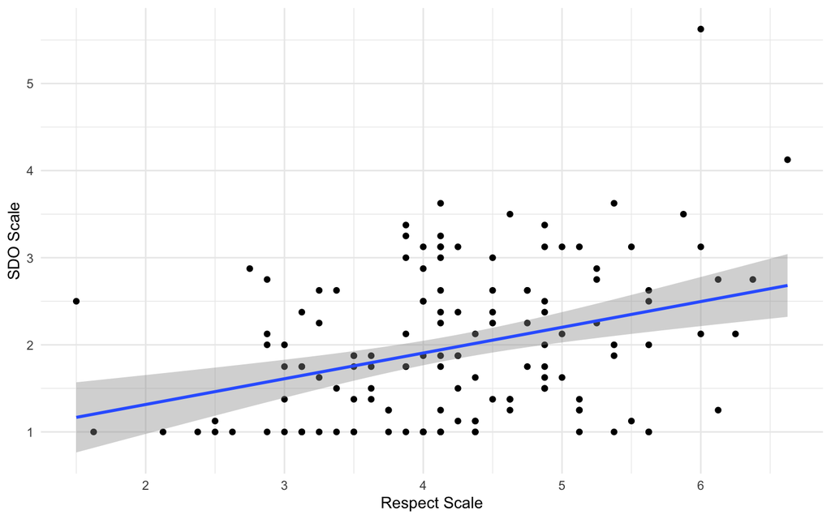

```r
ggplot(full.data, aes(x = RESPECT, y = SDO)) +
  geom_point() +
  theme_minimal() +
  geom_smooth(method = "lm") +
  labs(x = "Respect Scale", y = "SDO Scale")
```

### EXERCISE 10: GRAPH 1 INTERPRETATION

Above we see confirmation from our correlation analysis, there is a positive relationship between the two variables.

### EXERCISE 11: CORRELATION 2

Now, use cor.test() to find the correlation between `RESPECT` and one of the other 3 variables (must be different from the one used previously).

```r
cor.test(full.data$RESPECT, full.data$SJ)
```

```
##
##  Pearson's product-moment correlation
##
## data:  full.data$RESPECT and full.data$SJ
## t = 1.2763, df = 135, p-value = 0.204
## alternative hypothesis: true correlation is not equal to 0
## 95 percent confidence interval:
##  -0.05961339  0.27192934
## sample estimates:
##       cor
## 0.1091938
```

### EXERCISE 12: INTERPRET CORRELATION 1

There is NOT a statistically significant (p > 0.05) correlation (r = 0.11) between feelings about children needing to respect authority and system justification.

### EXERCISE 13: GRAPH 1

Next, create a scatterplot showing the relationship between these two variables. Make sure you: add a theme, add a `geom_smooth` line with method = “lm”, and clean up the labels for the x and y axis.

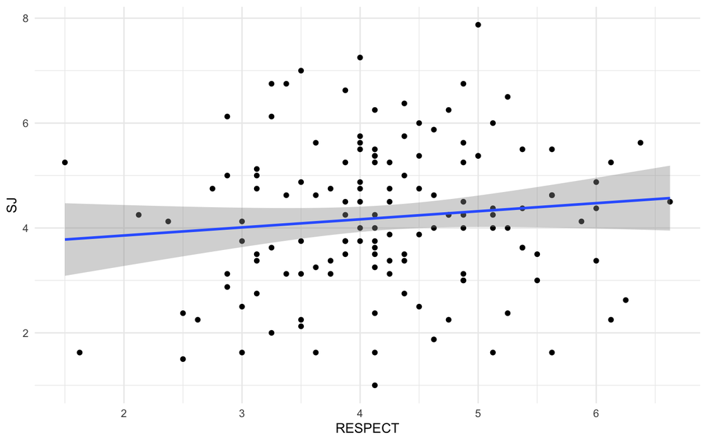

```r
ggplot(full.data, aes(x = RESPECT, y = SJ)) +
  geom_point() +
  theme_minimal() +
  geom_smooth(method = "lm")
```

### EXERCISE 14: GRAPH 2 INTERPRETATION

Confirming what we saw in the correlation analysis, there is no linear relationship between the respect and system justification variables.